# “Hongxiao Yu Final Report”

“Hongxiao Yu”

“2 May 2020”

### source function

```r
library(here)
source(here("Function", "function for analysis.R"))
```

### Part #l Data Preparation

*1.1 tidy the Job Prep Demographics* *1.1.1Import and tidy the Job Prep Demographics file into a tibble named “demo”.*

```r
# note that I have transfer the discipline column on Excel.
library(here)
library(tidyverse)
```

```r
demo <- read_csv(here("Data","Job Prep Demographics2.csv"),
                 skip = 5,
                 col_names = TRUE,
                 col_types = list(ID = col_double(),
                                  "School Code" = col_character(),
                                  Age = col_character(),
                                  Gender = col_character()))

demo
```

| ID | School Code | Age | Gender | Discipline |
| --- | --- | --- | --- | --- |
| 778 | 2 | 22 | m | Humanities |
| 459 | 1 | 21 | m | Humanities |
| 208 | 5 | 22 | f | Humanities |
| 342 | 10 | 22 | f | Humanities |
| 718 | 9 | 22 | m | Humanities |
| 824 | 18 | 21 | f | Humanities |
| 734 | 15 | 22 | m | Humanities |
| 477 | 9 | 22 | f | Humanities |
| 424 | 23 | 22 | f | Humanities |
| 577 | 11 | 22 | f | Humanities |

[output cut: 729 more lines]

*1.1.2 Eliminate rows with missing data*

```r
demo <- na.omit(demo)
demo
```

| ID | School Code | Age | Gender | Discipline |
| --- | --- | --- | --- | --- |
| 778 | 2 | 22 | m | Humanities |
| 459 | 1 | 21 | m | Humanities |
| 208 | 5 | 22 | f | Humanities |
| 342 | 10 | 22 | f | Humanities |
| 718 | 9 | 22 | m | Humanities |
| 824 | 18 | 21 | f | Humanities |
| 734 | 15 | 22 | m | Humanities |
| 477 | 9 | 22 | f | Humanities |
| 424 | 23 | 22 | f | Humanities |
| 577 | 11 | 22 | f | Humanities |

[output cut: 729 more lines]

*1.1.3 A primary key for the demo data is ID. Let’s make sure that we have a clean primary key.*

```r
check.demo <- demo %>%
  count(ID)
check.demo %>%
      filter(n > 1)
```

| ID | n |
| --- | --- |

*1.2 tidy Job Prep GPA Data* *1.2.1 Import and tidy Job Prep GPA Data file into a tibble named “gpa”.*

```r
gpa <- read_csv(here("Data","Job Prep GPA Data.csv"),
                 skip = 4,
                 col_names = TRUE,
                 col_types = list(ID = col_double(),
                                  "School Code" = col_character(),
                                  Age = col_character(),
                                  Gender = col_character()))

gpa
```

| ID | School Code | Age | Gender | S1 Credits | S1 GPA | S2 Credits | S2 GPA |
| --- | --- | --- | --- | --- | --- | --- | --- |
| 545 | 9 | 22 | f | 16 | 3.13 | 16 | 2.89 |
| 837 | 1 | 21 | m | 17 | 1.97 | 16 | 1.48 |
| 417 | 5 | 22 | m | 17 | 3.68 | 15 | 3.06 |
| 268 | 5 | 23 | m | 15 | 3.59 | 16 | 2.98 |
| 729 | 5 | 22 | f | 17 | 2.31 | 15 | 2.21 |
| 936 | 9 | 22 | f | 18 | 2.83 | 16 | 3.51 |
| 402 | 13 | 23 | m | 16 | 3.90 | 17 | 3.76 |
| 735 | 10 | 22 | f | 18 | 2.20 | 17 | 2.15 |
| 902 | 7 | 23 | f | 16 | 3.75 | 16 | 3.41 |
| 126 | 7 | 22 | m | 16 | 1.86 | 16 | 1.95 |

[output cut: 729 more lines]

*1.2.2 Let’s make sure that we have a clean key from the gpa file.*

```r
check.gpa <- gpa %>%
  count(ID)
check.gpa %>%
      filter(n > 1)
```

| ID | n |
| --- | --- |
| 659 | 2 |

*1.2.3 It seems there have two students who have the same ID. Let’s see what happened.*

```r
  subset(gpa, ID == 659)
```

| ID | School Code | Age | Gender | S1 Credits | S1 GPA | S2 Credits | S2 GPA |
| --- | --- | --- | --- | --- | --- | --- | --- |
| 659 | 5 | 22 | m | 18 | 3.08 | 16 | 2.77 |
| 659 | 4 | 21 | f | 15 | 3.05 | 17 | 2.97 |

```r
# Did we typed the wrong ID number? We can look at other data to check for that.
```

*1.2.4 Let’s compare gpa file with the demo file focusing on the student ID 659*

```r
subset(demo, ID == 659)
```

| ID | School Code | Age | Gender | Discipline |
| --- | --- | --- | --- | --- |
| 659 | 4 | 21 | f | Humanities |

*1.2.5 We just can find the student ID 659 in School Code 4. Let’s see if we could find if we type the wrong ID number in gpa file*

```r
subset (demo, "School Code" == 5, Age == 22, Gender = m)
```

```r
# We could not find the student ID 659 in School code 5. We should remove this row faom gpa data.
# If possilbe, I hope I could contact with the person who typed the data.
```

[output not shown]

*1.2.6 Let’s remove this row from gpa data.*

```r
gpa <- gpa %>%
  filter(!(ID == 659 & `School Code` == 5))
gpa
```

| ID | School Code | Age | Gender | S1 Credits | S1 GPA | S2 Credits | S2 GPA |
| --- | --- | --- | --- | --- | --- | --- | --- |
| 545 | 9 | 22 | f | 16 | 3.13 | 16 | 2.89 |
| 837 | 1 | 21 | m | 17 | 1.97 | 16 | 1.48 |
| 417 | 5 | 22 | m | 17 | 3.68 | 15 | 3.06 |
| 268 | 5 | 23 | m | 15 | 3.59 | 16 | 2.98 |
| 729 | 5 | 22 | f | 17 | 2.31 | 15 | 2.21 |
| 936 | 9 | 22 | f | 18 | 2.83 | 16 | 3.51 |
| 402 | 13 | 23 | m | 16 | 3.90 | 17 | 3.76 |
| 735 | 10 | 22 | f | 18 | 2.20 | 17 | 2.15 |
| 902 | 7 | 23 | f | 16 | 3.75 | 16 | 3.41 |
| 126 | 7 | 22 | m | 16 | 1.86 | 16 | 1.95 |

[output cut: 728 more lines]

*1.2.7 Let’s verify consistency between first and second semester. We could predict second semester GPA from first semester GPA*

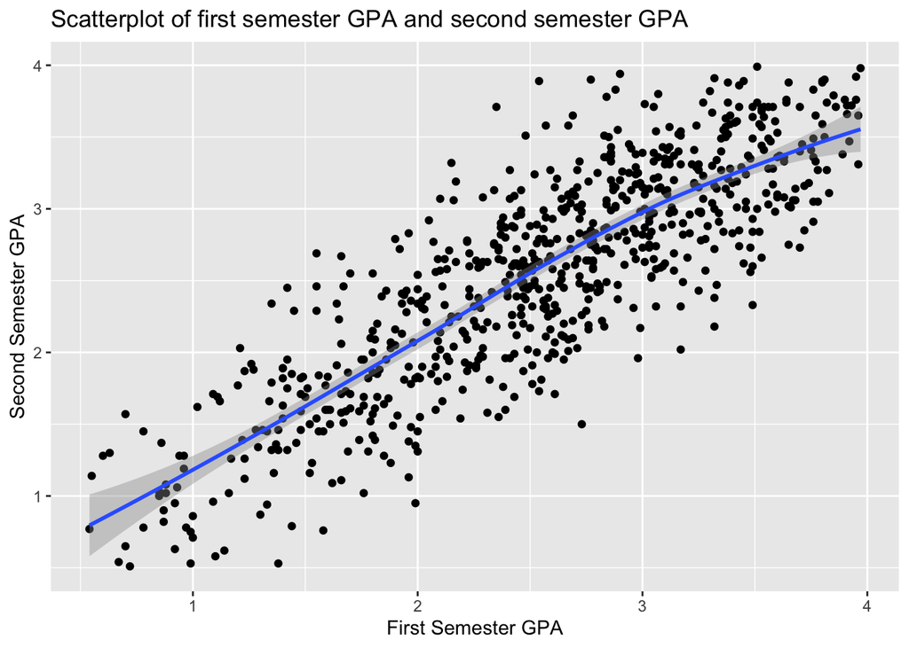

```r
ggplot(data = gpa, mapping = aes(x = `S1 GPA`, y = `S2 GPA`)) +
  geom_point() +
   labs(x= "First Semester GPA", y = "Second Semester GPA",
        title = "Scatterplot of first semester GPA and second semester GPA") +
  stat_smooth()
```

*1.2.8 Let’s average GPAs using a weighted average based on the number of credits taken in a semester.*

```r
gpa <- gpa %>%
  mutate(sygpa = (`S1 Credits`*`S1 GPA` + `S2 Credits`*`S2 GPA`)/(`S1 Credits` + `S2 Credits`) )
gpa
```

| ID | School Code | Age | Gender | S1 Credits | S1 GPA | S2 Credits | S2 GPA | sygpa |
| --- | --- | --- | --- | --- | --- | --- | --- | --- |
| 545 | 9 | 22 | f | 16 | 3.13 | 16 | 2.89 | 3.0100000 |
| 837 | 1 | 21 | m | 17 | 1.97 | 16 | 1.48 | 1.7324242 |
| 417 | 5 | 22 | m | 17 | 3.68 | 15 | 3.06 | 3.3893750 |
| 268 | 5 | 23 | m | 15 | 3.59 | 16 | 2.98 | 3.2751613 |
| 729 | 5 | 22 | f | 17 | 2.31 | 15 | 2.21 | 2.2631250 |
| 936 | 9 | 22 | f | 18 | 2.83 | 16 | 3.51 | 3.1500000 |
| 402 | 13 | 23 | m | 16 | 3.90 | 17 | 3.76 | 3.8278788 |
| 735 | 10 | 22 | f | 18 | 2.20 | 17 | 2.15 | 2.1757143 |
| 902 | 7 | 23 | f | 16 | 3.75 | 16 | 3.41 | 3.5800000 |
| 126 | 7 | 22 | m | 16 | 1.86 | 16 | 1.95 | 1.9050000 |

[output cut: 728 more lines]

*1.3 Import and tidy Job Prep Survey file* *1.3.1 import data and skip the title and empty rows*

```r
survey <- read_csv(here("Data","Job Prep Survey Results.csv"),
                 skip = 3,
                 col_names = TRUE)
```

*1.3.2 account for reverse-scored items*

```r
survey[, c("Item 4", "Item 9", "Item 12", "Item 13")] <-
  7 - survey[, c("Item 4", "Item 9", "Item 12", "Item 13")]

survey
```

| ID | Item 1 | Item 2 | Item 3 | Item 4 | Item 5 | Item 6 | Item 7 | Item 8 | Item 9 | Item 10 | Item 11 | Item 12 | Item 13 | Item 14 |
| --- | --- | --- | --- | --- | --- | --- | --- | --- | --- | --- | --- | --- | --- | --- |
| 653 | 2 | 5 | 5 | 4 | 4 | 4 | 6 | 5 | 2 | 2 | 5 | 5 | 6 | 6 |
| 478 | 2 | 1 | 5 | 3 | 1 | 4 | 5 | 6 | 2 | 3 | 5 | 5 | 3 | 3 |
| 247 | 5 | 5 | 6 | 4 | 6 | 2 | 4 | 5 | 3 | 5 | 6 | 5 | 3 | 5 |
| 934 | 4 | 3 | 3 | 4 | 1 | 2 | 3 | 6 | 3 | 2 | 3 | 4 | 3 | 6 |
| 971 | 4 | 6 | 3 | 2 | 3 | 1 | 3 | 2 | 3 | 2 | 2 | 4 | 2 | 2 |
| 750 | 1 | 6 | 4 | 2 | 5 | 3 | 5 | 5 | 3 | 3 | 4 | 3 | 2 | 3 |
| 919 | 4 | 6 | 1 | 2 | 1 | 3 | 2 | 3 | 3 | 4 | 4 | 3 | 6 | 2 |
| 306 | 4 | 5 | 4 | 2 | 4 | 3 | 3 | 2 | 3 | 2 | 5 | 6 | 6 | 2 |
| 389 | 3 | 1 | 1 | 5 | 5 | 5 | 3 | 6 | 4 | 5 | 2 | 5 | 5 | 5 |
| 859 | 6 | 3 | 4 | 2 | 5 | 4 | 4 | 3 | 2 | 6 | 1 | 6 | 6 | 6 |

[output cut: 523 more lines]

*1.3.3 sum the items as an indicator of optimism about future job prospects*

```r
survey <- survey %>%
  mutate(optimism = rowSums(select(., 2:15)))

survey
```

| ID | Item 1 | Item 2 | Item 3 | Item 4 | Item 5 | Item 6 | Item 7 | Item 8 | Item 9 | Item 10 | Item 11 | Item 12 | Item 13 | Item 14 | optimism |
| --- | --- | --- | --- | --- | --- | --- | --- | --- | --- | --- | --- | --- | --- | --- | --- |
| 653 | 2 | 5 | 5 | 4 | 4 | 4 | 6 | 5 | 2 | 2 | 5 | 5 | 6 | 6 | 61 |
| 478 | 2 | 1 | 5 | 3 | 1 | 4 | 5 | 6 | 2 | 3 | 5 | 5 | 3 | 3 | 48 |
| 247 | 5 | 5 | 6 | 4 | 6 | 2 | 4 | 5 | 3 | 5 | 6 | 5 | 3 | 5 | 64 |
| 934 | 4 | 3 | 3 | 4 | 1 | 2 | 3 | 6 | 3 | 2 | 3 | 4 | 3 | 6 | 47 |
| 971 | 4 | 6 | 3 | 2 | 3 | 1 | 3 | 2 | 3 | 2 | 2 | 4 | 2 | 2 | 39 |
| 750 | 1 | 6 | 4 | 2 | 5 | 3 | 5 | 5 | 3 | 3 | 4 | 3 | 2 | 3 | 49 |
| 919 | 4 | 6 | 1 | 2 | 1 | 3 | 2 | 3 | 3 | 4 | 4 | 3 | 6 | 2 | 44 |
| 306 | 4 | 5 | 4 | 2 | 4 | 3 | 3 | 2 | 3 | 2 | 5 | 6 | 6 | 2 | 51 |
| 389 | 3 | 1 | 1 | 5 | 5 | 5 | 3 | 6 | 4 | 5 | 2 | 5 | 5 | 5 | 55 |
| 859 | 6 | 3 | 4 | 2 | 5 | 4 | 4 | 3 | 2 | 6 | 1 | 6 | 6 | 6 | 58 |

[output cut: 523 more lines]

*1.3.4 Let’s make sure that we have a clean key from the survey file.*

```r
check.survey <- survey %>%
  count(ID)
check.survey %>%
      filter(n > 1)
```

| ID | n |
| --- | --- |

*1.4 Let’s combine the data.*

```r
data <-
  demo %>%
  left_join(gpa) %>%
  left_join(survey)
data
```

| ID | School Code | Age | Gender | Discipline | S1 Credits | S1 GPA | S2 Credits | S2 GPA | sygpa | Item 1 | Item 2 | Item 3 | Item 4 | Item 5 | Item 6 | Item 7 | Item 8 | Item 9 | Item 10 | Item 11 | Item 12 | Item 13 | Item 14 | optimism |
| --- | --- | --- | --- | --- | --- | --- | --- | --- | --- | --- | --- | --- | --- | --- | --- | --- | --- | --- | --- | --- | --- | --- | --- | --- |
| 778 | 2 | 22 | m | Humanities | 16 | 2.22 | 16 | 1.87 | 2.0450000 | 3 | 4 | 3 | 1 | 5 | 2 | 5 | 1 | 2 | 2 | 1 | 5 | 4 | 3 | 41 |
| 459 | 1 | 21 | m | Humanities | 16 | 2.29 | 13 | 2.63 | 2.4424138 | 2 | 3 | 2 | 2 | 1 | 5 | 6 | 3 | 3 | 4 | 3 | 3 | 2 | 5 | 44 |
| 208 | 5 | 22 | f | Humanities | 16 | 2.41 | 15 | 2.54 | 2.4729032 | 4 | 5 | 2 | 1 | 2 | 3 | 1 | 2 | 5 | 2 | 6 | 2 | 1 | 1 | 37 |
| 342 | 10 | 22 | f | Humanities | 17 | 3.52 | 15 | 3.59 | 3.5528125 | 1 | 1 | 5 | 1 | 2 | 3 | 3 | 3 | 1 | 2 | 4 | 5 | 2 | 5 | 38 |
| 718 | 9 | 22 | m | Humanities | 17 | 1.80 | 16 | 1.42 | 1.6157576 | NA | NA | NA | NA | NA | NA | NA | NA | NA | NA | NA | NA | NA | NA | NA |
| 824 | 18 | 21 | f | Humanities | 12 | 3.44 | 15 | 3.29 | 3.3566667 | 1 | 2 | 3 | 3 | 3 | 5 | 1 | 1 | 5 | 1 | 3 | 2 | 2 | 1 | 33 |
| 734 | 15 | 22 | m | Humanities | 15 | 2.58 | 16 | 2.38 | 2.4767742 | 1 | 4 | 2 | 3 | 3 | 3 | 2 | 2 | 1 | 3 | 1 | 3 | 5 | 4 | 37 |
| 477 | 9 | 22 | f | Humanities | 13 | 1.21 | 16 | 2.03 | 1.6624138 | 5 | 2 | 2 | 4 | 3 | 3 | 3 | 4 | 3 | 1 | 4 | 5 | 4 | 2 | 45 |
| 424 | 23 | 22 | f | Humanities | 15 | 2.73 | 16 | 2.26 | 2.4874194 | 3 | 3 | 1 | 2 | 4 | 4 | 6 | 3 | 4 | 4 | 4 | 3 | 3 | 1 | 45 |
| 577 | 11 | 22 | f | Humanities | 16 | 1.70 | 17 | 2.55 | 2.1378788 | NA | NA | NA | NA | NA | NA | NA | NA | NA | NA | NA | NA | NA | NA | NA |

[output cut: 729 more lines]

*1.5 Make the missing data explicit*

```r
data <- data[complete.cases(data),]
sum(table(data$ID)) == length(data$ID)
```

```
## [1] TRUE
```

```r
data
```

| ID | School Code | Age | Gender | Discipline | S1 Credits | S1 GPA | S2 Credits | S2 GPA | sygpa | Item 1 | Item 2 | Item 3 | Item 4 | Item 5 | Item 6 | Item 7 | Item 8 | Item 9 | Item 10 | Item 11 | Item 12 | Item 13 | Item 14 | optimism |
| --- | --- | --- | --- | --- | --- | --- | --- | --- | --- | --- | --- | --- | --- | --- | --- | --- | --- | --- | --- | --- | --- | --- | --- | --- |
| 778 | 2 | 22 | m | Humanities | 16 | 2.22 | 16 | 1.87 | 2.0450000 | 3 | 4 | 3 | 1 | 5 | 2 | 5 | 1 | 2 | 2 | 1 | 5 | 4 | 3 | 41 |
| 459 | 1 | 21 | m | Humanities | 16 | 2.29 | 13 | 2.63 | 2.4424138 | 2 | 3 | 2 | 2 | 1 | 5 | 6 | 3 | 3 | 4 | 3 | 3 | 2 | 5 | 44 |
| 208 | 5 | 22 | f | Humanities | 16 | 2.41 | 15 | 2.54 | 2.4729032 | 4 | 5 | 2 | 1 | 2 | 3 | 1 | 2 | 5 | 2 | 6 | 2 | 1 | 1 | 37 |
| 342 | 10 | 22 | f | Humanities | 17 | 3.52 | 15 | 3.59 | 3.5528125 | 1 | 1 | 5 | 1 | 2 | 3 | 3 | 3 | 1 | 2 | 4 | 5 | 2 | 5 | 38 |
| 824 | 18 | 21 | f | Humanities | 12 | 3.44 | 15 | 3.29 | 3.3566667 | 1 | 2 | 3 | 3 | 3 | 5 | 1 | 1 | 5 | 1 | 3 | 2 | 2 | 1 | 33 |
| 734 | 15 | 22 | m | Humanities | 15 | 2.58 | 16 | 2.38 | 2.4767742 | 1 | 4 | 2 | 3 | 3 | 3 | 2 | 2 | 1 | 3 | 1 | 3 | 5 | 4 | 37 |
| 477 | 9 | 22 | f | Humanities | 13 | 1.21 | 16 | 2.03 | 1.6624138 | 5 | 2 | 2 | 4 | 3 | 3 | 3 | 4 | 3 | 1 | 4 | 5 | 4 | 2 | 45 |
| 424 | 23 | 22 | f | Humanities | 15 | 2.73 | 16 | 2.26 | 2.4874194 | 3 | 3 | 1 | 2 | 4 | 4 | 6 | 3 | 4 | 4 | 4 | 3 | 3 | 1 | 45 |
| 103 | 16 | 21 | m | Humanities | 16 | 1.67 | 16 | 2.46 | 2.0650000 | 1 | 4 | 5 | 2 | 2 | 6 | 2 | 2 | 4 | 1 | 3 | 1 | 5 | 5 | 43 |
| 113 | 12 | 21 | m | Humanities | 16 | 1.84 | 16 | 2.39 | 2.1150000 | 1 | 1 | 3 | 3 | 1 | 2 | 1 | 5 | 5 | 4 | 2 | 3 | 1 | 4 | 36 |

[output cut: 522 more lines]

```r
# 532/739 = 72%
# It is consistent with Mr Habernooth's letther, the response rate is 72%.
```

### Section #2

### Question 1: Is senior-year grade point average (GPA) related to the degree of optimism about future employment?

*2.1 Scatterplot of Senior-year GPA and optimism*

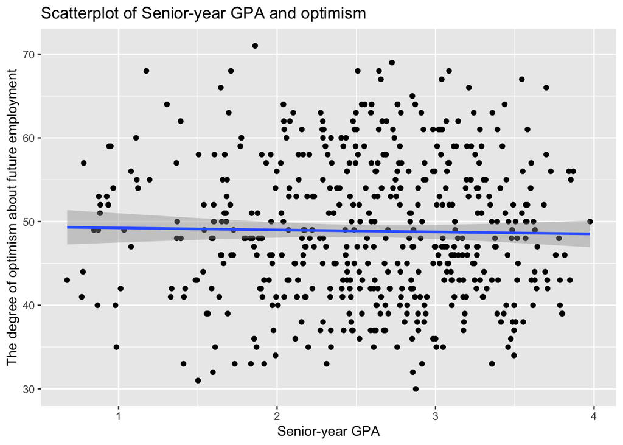

```r
ggplot(data = data, mapping = aes(x = sygpa, y = optimism)) +
  geom_point() +
   labs(x= "Senior-year GPA", y = "The degree of optimism about future employment",
        title = "Scatterplot of Senior-year GPA and optimism") +
  stat_smooth(method = "lm")
```

```r
# From the scateerpoint, It seems senior-year grade point average (GPA) is not tightly related to the degree of optimism about future employment.
```

*2.2 Correlation of senior-year GPA and optimism*

```r
cor(data$sygpa,data$optimism)
```

```
## [1] -0.0202027
```

```r
# The correlation of senior-year GPA and optimism is in the lower level.
```

*2.3 Model summary*

```r
model1 <- lm(data$optimism ~ data$sygpa)
summary(model1)
```

```
##
## Call:
## lm(formula = data$optimism ~ data$sygpa)
##
## Residuals:
##      Min       1Q   Median       3Q      Max
## -18.7915  -6.7236  -0.8192   6.2869  21.9650
##
## Coefficients:
##             Estimate Std. Error t value Pr(>|t|)
## (Intercept)  49.4824     1.3771  35.931   <2e-16 ***
## data$sygpa   -0.2403     0.5166  -0.465    0.642
## ---
## Signif. codes:  0 '***' 0.001 '**' 0.01 '*' 0.05 '.' 0.1 ' ' 1
##
## Residual standard error: 8.424 on 530 degrees of freedom
## Multiple R-squared:  0.0004081,  Adjusted R-squared:  -0.001478
## F-statistic: 0.2164 on 1 and 530 DF,  p-value: 0.642
```

```r
# p = 0.642 > 0.01, we conclude that senior-year grade point average (GPA) is not significantly related to the degree of optimism about future employment.
```

*2.4 Q-Q plot for residuals in the study of senior-year GPA and optimism*

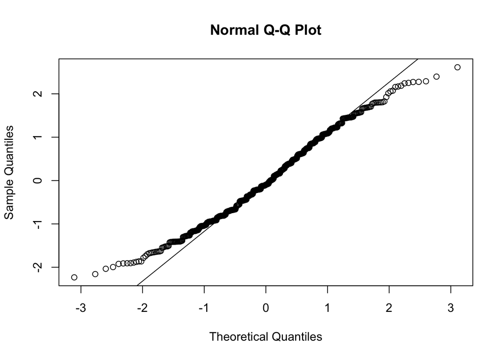

```r
std_residual <- rstandard(model1)
qqnorm(std_residual)
qqline(std_residual)
```

```r
# It seems there is the higher tails for Q-Q plot.
```

### Section #3

### Question 2: Is the relationship of GPA and optimism consistent or different for different categories of disciplines?

*3.1 Boxplot of optimism scores by Disciplines*

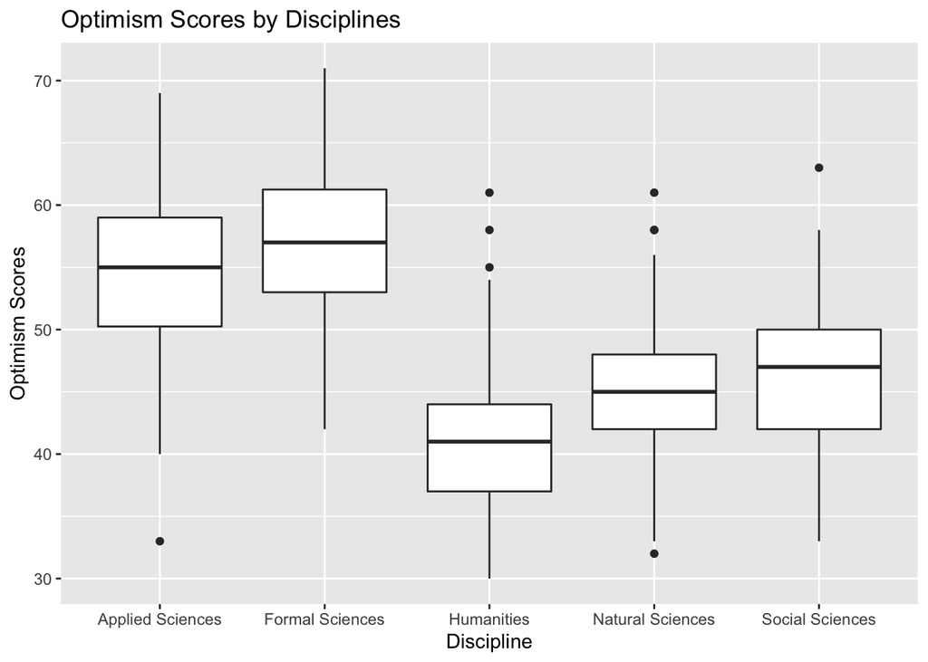

```r
ggplot(data, aes(x = Discipline, y = optimism)) +
  geom_boxplot() +
  labs(x= "Discipline", y = "Optimism Scores",
        title = "Optimism Scores by Disciplines")
```

*3.2 Summary data for optimism and discipline*

```r
tapply(data$optimism, data$Discipline, summary)
```

```
## $`Applied Sciences`
##    Min. 1st Qu.  Median    Mean 3rd Qu.    Max.
##   33.00   50.25   55.00   54.78   59.00   69.00
##
## $`Formal Sciences`
##    Min. 1st Qu.  Median    Mean 3rd Qu.    Max.
##   42.00   53.00   57.00   56.96   61.25   71.00
##
## $Humanities
##    Min. 1st Qu.  Median    Mean 3rd Qu.    Max.
##    30.0    37.0    41.0    41.1    44.0    61.0
##
## $`Natural Sciences`
##    Min. 1st Qu.  Median    Mean 3rd Qu.    Max.
##      32      42      45      45      48      61
##
## $`Social Sciences`
##    Min. 1st Qu.  Median    Mean 3rd Qu.    Max.
##   33.00   42.00   47.00   46.43   50.00   63.00
```

```r
tapply(data$optimism, data$Discipline, sd)
```

```
## Applied Sciences  Formal Sciences       Humanities Natural Sciences
##         6.533429         6.176419         5.540485         5.477226
##  Social Sciences
##         5.940082
```

*3.3 Boxplot of Senior-year GPA by Disciplines*

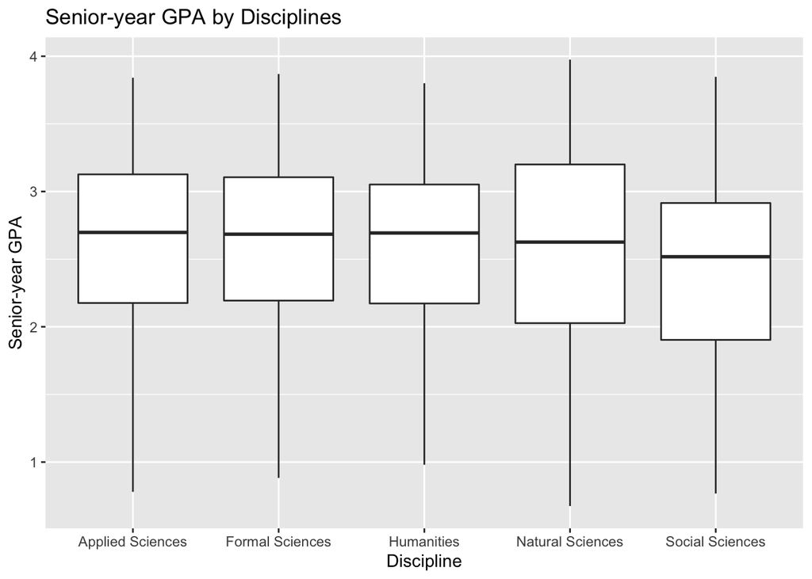

```r
ggplot(data, aes(x = Discipline, y = sygpa)) +
  geom_boxplot() +
  labs(x= "Discipline", y = "Senior-year GPA",
        title = "Senior-year GPA by Disciplines")
```

*3.4 Summary data for Senior-year and discipline*

```r
tapply(data$sygpa, data$Discipline, summary)
```

```
## $`Applied Sciences`
##    Min. 1st Qu.  Median    Mean 3rd Qu.    Max.
##   0.780   2.176   2.698   2.574   3.127   3.841
##
## $`Formal Sciences`
##    Min. 1st Qu.  Median    Mean 3rd Qu.    Max.
##  0.8829  2.1935  2.6843  2.6084  3.1054  3.8686
##
## $Humanities
##    Min. 1st Qu.  Median    Mean 3rd Qu.    Max.
##   0.980   2.172   2.693   2.643   3.052   3.800
##
## $`Natural Sciences`
##    Min. 1st Qu.  Median    Mean 3rd Qu.    Max.
##   0.675   2.027   2.626   2.594   3.200   3.975
##
## $`Social Sciences`
##    Min. 1st Qu.  Median    Mean 3rd Qu.    Max.
##  0.7674  1.9032  2.5179  2.4382  2.9150  3.8478
```